# Gene Set Enrichement and Network Analysis

BCB420 Assignment 3

Jielin Yang

April 4th, 2023

# 1 Introduction

## 1.1 Background

Heart failure (HF) is a chronic cardiac disease with complex pathophysiology with profound implications in the patient’s quality of life. The progressively degenerating myocardium is a major hallmark of HF, which is accompanied by cardiac fibrosis.<sup>1</sup> <sup>2</sup><sup>3</sup> Therefore, the identification of profibrotic pathways is essential to the understanding the pathophysiology of HF and the development of therapeutic strategies to delay or even to prevent the profibrotic remodelling of the heart.

The Hippo pathway is a conserved signalling pathway that regulates cell proliferation, cell survival, and cell migration.<sup>4</sup> It has been previously discovered that a central component of this pathway, the YAP/TAZ complex, is dysregulated upon mechanimal stimulation of the cytoskeleton.<sup>5</sup> <sup>6</sup><sup>7</sup> Interestingly, heart failure is usually accompanied by mechanical stress due to the malfunctioning of the pumping capability of the heart. Therefore, the direct suppression of the YAP/TAZ complex may be a potential therapeutic approach to suppress the proliferation of pro-fibrotic cells and to prevent the profibrotic remodelling of the heart.<sup>1</sup> Recently, [Garoffolo et al.](https://www.ahajournals.org/doi/10.1161/CIRCRESAHA.121.319373) investigated the use of a small molecular inhibitor, verteporfin (VTP) in cardiac stromal cells, an important precursor to cardiac fibroblasts, to suppress the YAP/TAZ complex with or without the presence of TGF-β1, a profibrotic cytokine under the maximal strain condition.

## 1.2 Objectives

In the present analysis, we aim to use RNA-seq data to identify the changes in the transcriptional profile of cardiac stromal cells after the use of VTP. As shown in Figure 1., the transcriptome was assessed by comparing the addition of VTP with the control with or without the presence of the profibrotic cytokine, TGF-β1.<sup>8</sup> Upon the identification of differentially expressed genes, we aim to perform gene set enrichment analysis (GSEA) and network analysis to access the enriched pathways and using it to infer the molecular mechanisms underlying the effects of VTP on cardiac stromal cells.

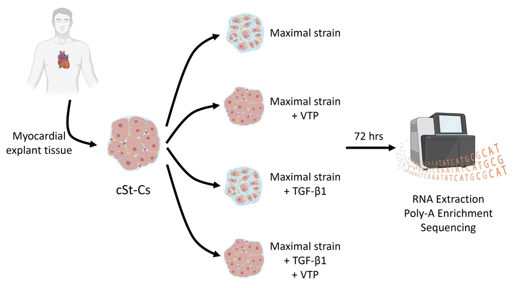

**Figure 1.** Schematics of RNAseq experiment design. Samples were cultured under maximal mechanical strains. Six independent cell cultures were used for each treatment condition. cSt-Cs: cardiospheres-derived primitive cardiac stromal cells; VTP: verteporfin; TGF-β1: transforming growth factor beta-1. Figure adapted from [Assignment 1](https://github.com/bcb420-2023/Jielin_Yang/blob/main/Dataset%20selection%20and%20initial%20processing/Assignment_1_Data_cleaning_and_identifier_mapping.html) and created with BioRender.com.

## 1.3 Dataset

The data used in the present analysis is retrieved from the GEO database under the accession number GSE203358. The dataset contains RNA-seq data from 24 samples, which are evenly split into 4 groups: * Control (maximal strain condition) * Verteporfin (VTP) treatment (maximal strain condition) * TGF-β1 treatment (maximal strain condition) * Verteporfin (VTP) treatment with TGF-β1 (maximal strain condition)

## 1.4 Previous Analysis

### 1.4.1 Data Normalization

Upon filtering out genes with low counts, the dataset is composed of `14814` genes and `24` samples. The reference genome used is the human [GRCh38](https://useast.ensembl.org/Homo_sapiens/Info/Index?db=core).

The dataset was normalized using the Trimmed Mean of M-values (TMM) method implemented by the [edgeR](https://bioconductor.org/packages/release/bioc/html/edgeR.html) package.<sup>9</sup> After applying normalization, the library size for each sample has been effectively adjusted such that the distribution of gene expressions are comparable across samples.

### 1.4.2 Cluster Analysis

Samples were clustered based on transcriptional similarity. multidimensional scaling analysis indicates distinct separation based on treatment conditions, with the most highly distinguishable cluster of samples in the control group, without profibrotic TGF-β1 treatment. Additional hierarchical clustering with heatmap further supports that the control group has the most distinguishable transcriptome, with few samples having similar expression patterns with the other groups. VTP treatment are found to alter the transcriptional profile to an high extent, but its effect is less prominent when combined with TGF-β1. In addition, the samples show moderate to low degree of clustering based on the cell culture replicates, suggesting that the variation between samples are less driven by the intrinsic biological variation between the cell cultures.

### 1.4.3 Differential Expression Analysis and Preliminary ORA

Differential gene expression analysis was performed using the `edgeR` package.<sup>9</sup> Figure 2. shows the volcano plot of the differentially expressed genes (DEGs) between the control and VTP treatment groups, with the top enriched GO: Biological Process terms in the significantly downregulated genes. In this analysis, 1040 genes are found to be differentially expressed between the control and VTP treatment group, without the presence of TGF-β1. Among these genes, 605 are significantly upregulated and 435 are significantly downregulated. Many of the downregulated genes are collagen genes, which are a major component of the extracellular matrix (ECM) and are involved in the profibrotic remodelling of the heart.<sup>1</sup> The top enriched GO: Biological Process terms are also consistent with such findings, showing pathways in cell adhesion and ECM organization. However, when TGF-β1 is added, the effect of VTP is much less pronounced, with only 14 genes being differentially expressed.

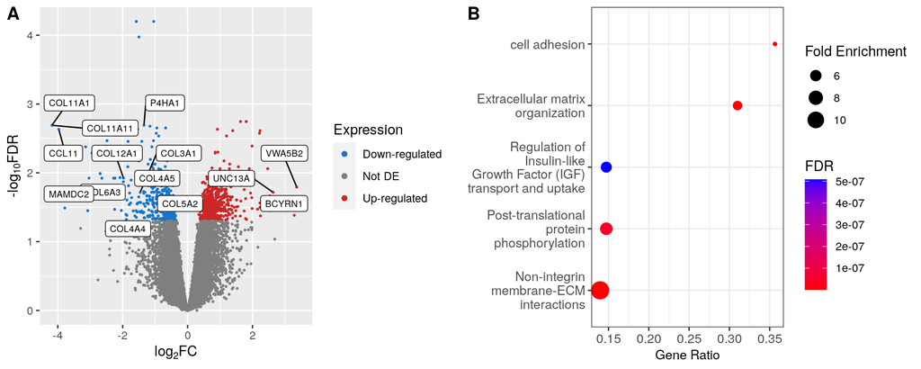

**Figure 2.** Differentially expressed genes and enriched GO: Biological Process terms in the significantly downregulated genes. (A) Volcano plot of the differentially expressed genes between the control and VTP treatment groups in the absence of TGF-β1. Important genes are labelled, with most collagen genes found to be downregulated. (B) Dot plot of the top 5 enriched GO: Biological Process terms in the significantly downregulated genes.

# 2 Preparations

## 2.1 Package Dependencies

The current R Notebook assumes that it is being run on the BCB420-2023 base image. Additional packages required are noted below. For reproducibility we list all packages we used in the analysis, including utility packages. The GSEA and Cytoscape softwares with the EnrichmentMap pipeline are also required for the analysis, but they are run manually outside of the R Notebook.

```r
# ggplot2 package for creating plots
if (!requireNamespace("ggplot2", quietly = TRUE)) {
    install.packages("ggplot2")
}
# cowplot package for arranging plots
if (!requireNamespace("cowplot", quietly = TRUE)) {
    install.packages("cowplot")
}
# ggrepel package for plotting text with minimal overlap
if (!requireNamespace("ggrepel", quietly = TRUE)) {
    install.packages("ggrepel")
}
# KableExtra package for creating tables and formatting
if (!requireNamespace("kableExtra", quietly = TRUE)) {
    install.packages("kableExtra")
}
# dplyr package for data manipulation
if (!requireNamespace("dplyr", quietly = TRUE)) {
    install.packages("dplyr")
}
# DT package for creating interactive tables
if (!requireNamespace("DT", quietly = TRUE)) {
    install.packages("DT")
}

# Load the packages
library("dplyr")
library("ggplot2")

# We will consistently use package::function() to avoid confusion However, the
# dplyr package has to be loaded first to allow definitions of various
# operators such as %>%
```

## 2.2 Data Preparation

Since our current analysis is dependent upon the differential gene expression analysis from assignment 2, we will load the data from the previous assignment.

```r
# Load the differential gene expression analysis results from assignment 2

# Comparison between control and VTP without TGF-β1
deg_vtp_ctrl <- read.csv("./Data/dge_vtp_ctrl.csv", row.names = 1, header = TRUE,
    stringsAsFactors = FALSE, check.names = FALSE)

# Comparison between control and VTP with TGF-β1
deg_vtp_tgf <- read.csv("./Data/dge_vtp_tgf.csv", row.names = 1, header = TRUE, stringsAsFactors = FALSE,
    check.names = FALSE)
```

The data we just loaded are produced from the `topTags` function in the `edgeR` package, which returns the log fold change, unadjusted p-value, and adjusted p-value (FDR) for each gene.